# Summary of “A Comparison of 12 Algorithms for Matching on the Propensity Score”

# 4 Case Study

Most materials were adopted from https://argoshare.is.ed.ac.uk/healthyr_book/chap11- h1.html

```r
# Load and examine the colon_s dataset
dim(colon_s) # Display dimensions of the dataset
```

```
[1] 929  32
```

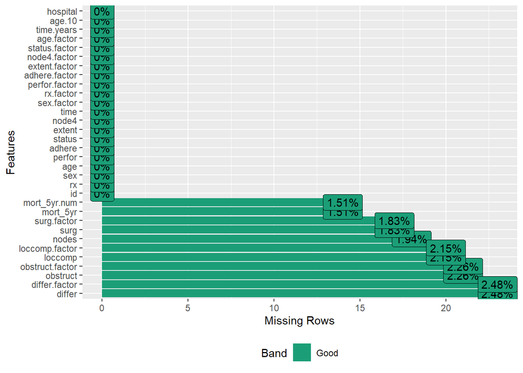

```r
DataExplorer::plot_missing(colon_s) # Visualize missing data in the dataset
```

```r
str(colon_s) # Display the structure of the dataset
```

```
'data.frame':   929 obs. of  32 variables:
 $ id             : num  1 2 3 4 5 6 7 8 9 10 ...
 $ rx             : Factor w/ 3 levels "Obs","Lev","Lev+5FU": 3 3 1 3 1 3 2 1 2 3 ...
 $ sex            : num  1 1 0 0 1 0 1 1 1 0 ...
 $ age            : num  43 63 71 66 69 57 77 54 46 68 ...
  ..- attr(*, "label")= chr "Age (years)"
 $ obstruct       : num  NA 0 0 1 0 0 0 0 0 0 ...
 $ perfor         : num  0 0 0 0 0 0 0 0 0 0 ...
 $ adhere         : num  0 0 1 0 0 0 0 0 1 0 ...
 $ nodes          : num  5 1 7 6 22 9 5 1 2 1 ...
 $ status         : num  1 0 1 1 1 1 1 0 0 0 ...
 $ differ         : num  2 2 2 2 2 2 2 2 2 2 ...
 $ extent         : num  3 3 2 3 3 3 3 3 3 3 ...
 $ surg           : num  0 0 0 1 1 0 1 0 0 1 ...
 $ node4          : num  1 0 1 1 1 1 1 0 0 0 ...
 $ time           : num  1521 3087 963 293 659 ...
 $ sex.factor     : Factor w/ 2 levels "Female","Male": 2 2 1 1 2 1 2 2 2 1 ...
  ..- attr(*, "label")= chr "Sex"
 $ rx.factor      : Factor w/ 3 levels "Obs","Lev","Lev+5FU": 3 3 1 3 1 3 2 1 2 3 ...
  ..- attr(*, "label")= chr "Treatment"
 $ obstruct.factor: Factor w/ 2 levels "No","Yes": NA 1 1 2 1 1 1 1 1 1 ...
  ..- attr(*, "label")= chr "Obstruction"
 $ perfor.factor  : Factor w/ 2 levels "No","Yes": 1 1 1 1 1 1 1 1 1 1 ...
  ..- attr(*, "label")= chr "Perforation"
 $ adhere.factor  : Factor w/ 2 levels "No","Yes": 1 1 2 1 1 1 1 1 2 1 ...
  ..- attr(*, "label")= chr "Adherence"
 $ differ.factor  : Factor w/ 3 levels "Well","Moderate",..: 2 2 2 2 2 2 2 2 2 2 ...
  ..- attr(*, "label")= chr "Differentiation"
 $ extent.factor  : Factor w/ 4 levels "Submucosa","Muscle",..: 3 3 2 3 3 3 3 3 3 3 ...
  ..- attr(*, "label")= chr "Extent of spread"
 $ surg.factor    : Factor w/ 2 levels "Short","Long": 1 1 1 2 2 1 2 1 1 2 ...
  ..- attr(*, "label")= chr "Time from surgery"
 $ node4.factor   : Factor w/ 2 levels "No","Yes": 2 1 2 2 2 2 2 1 1 1 ...
  ..- attr(*, "label")= chr ">4 positive nodes"
 $ status.factor  : Factor w/ 2 levels "Alive","Died": 2 1 2 2 2 2 2 1 1 1 ...
  ..- attr(*, "label")= chr "Status"
 $ age.factor     : Factor w/ 3 levels "<40 years","40-59 years",..: 2 3 3 3 3 2 3 2 2 3 ...
  ..- attr(*, "label")= chr "Age"
 $ loccomp        : num  NA 0 1 1 0 0 0 0 1 0 ...
 $ loccomp.factor : Factor w/ 2 levels "No","Yes": NA 1 2 2 1 1 1 1 2 1 ...
  ..- attr(*, "label")= chr "Local complications"
 $ time.years     : num  4.167 8.458 2.638 0.803 1.805 ...
  ..- attr(*, "label")= chr "Time (years)"
 $ mort_5yr       : Factor w/ 2 levels "Alive","Died": 2 1 2 2 2 2 2 1 1 1 ...
  ..- attr(*, "label")= chr "Mortality 5 year"
 $ age.10         : num  4.3 6.3 7.1 6.6 6.9 5.7 7.7 5.4 4.6 6.8 ...
 $ mort_5yr.num   : num  2 1 2 2 2 2 2 1 1 1 ...
 $ hospital       : Factor w/ 5 levels "hospital_1","hospital_2",..: 5 3 5 4 5 4 2 2 2 2 ...
```

```r
# Set seed for reproducibility
set.seed(1)

# Manipulate the dataset to introduce additional missing data
colon_s <- colon_s %>%
  mutate(
    # Introducing missing data for 'smoking' completely at random
    smoking_mcar = sample(c("Smoker", "Non-smoker", NA), n(), replace = TRUE,
                          prob = c(0.2, 0.7, 0.1)) %>%
      factor() %>%
      ff_label("Smoking (MCAR)"),

    # Introducing missing data for 'smoking' conditional on patient sex
    smoking_mar = ifelse(sex.factor == "Female",
                         sample(c("Smoker", "Non-smoker", NA),
                                sum(sex.factor == "Female"), replace = TRUE,
                                prob = c(0.1, 0.5, 0.4)),
                         sample(c("Smoker", "Non-smoker", NA),
                                sum(sex.factor == "Male"), replace = TRUE,
                                prob = c(0.15, 0.75, 0.1))) %>%
      factor() %>%
      ff_label("Smoking (MAR)")
  )

# Display the updated dimensions of the dataset to check for changes
dim(colon_s) # Chemotherapy for Stage B/C colon cancer
```

```
[1] 929  34
```

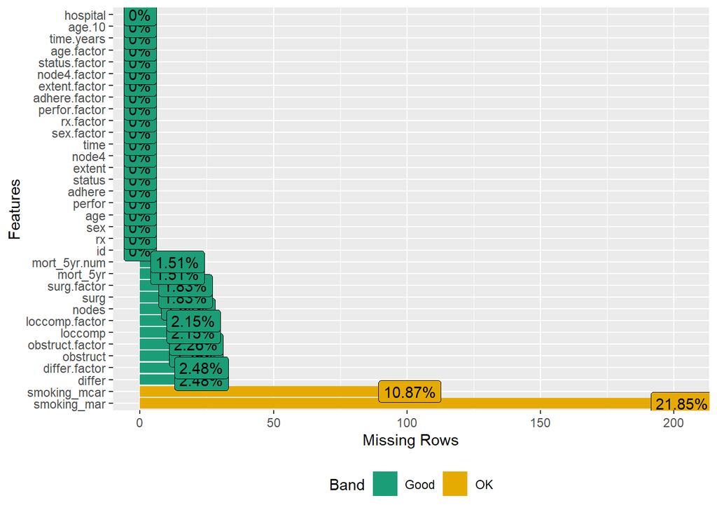

```r
# Re-visualize missing data in the modified dataset
DataExplorer::plot_missing(colon_s)
```

```r
# Use the ff_glimpse() function to examine the variables of interest.
explanatory <- c("age", "sex.factor", "nodes", "obstruct.factor",
"smoking_mcar", "smoking_mar")
dependent <- "mort_5yr"

colon_s %>%
ff_glimpse(dependent, explanatory)
```

```
$Continuous
            label var_type   n missing_n missing_percent mean   sd  min
age   Age (years)    <dbl> 929         0             0.0 59.8 11.9 18.0
nodes       nodes    <dbl> 911        18             1.9  3.7  3.6  0.0
      quartile_25 median quartile_75  max
age          53.0   61.0        69.0 85.0
nodes         1.0    2.0         5.0 33.0

$Categorical
                           label var_type   n missing_n missing_percent
mort_5yr        Mortality 5 year    <fct> 915        14             1.5
sex.factor                   Sex    <fct> 929         0             0.0
obstruct.factor      Obstruction    <fct> 908        21             2.3
smoking_mcar      Smoking (MCAR)    <fct> 828       101            10.9
smoking_mar        Smoking (MAR)    <fct> 726       203            21.9
                levels_n                              levels  levels_count
mort_5yr               2        "Alive", "Died", "(Missing)"  511, 404, 14
sex.factor             2       "Female", "Male", "(Missing)"      445, 484
obstruct.factor        2            "No", "Yes", "(Missing)"  732, 176, 21
smoking_mcar           2 "Non-smoker", "Smoker", "(Missing)" 645, 183, 101
smoking_mar            2 "Non-smoker", "Smoker", "(Missing)" 585, 141, 203
                  levels_percent
mort_5yr        55.0, 43.5,  1.5
sex.factor                48, 52
obstruct.factor 78.8, 18.9,  2.3
smoking_mcar          69, 20, 11
smoking_mar           63, 15, 22
```

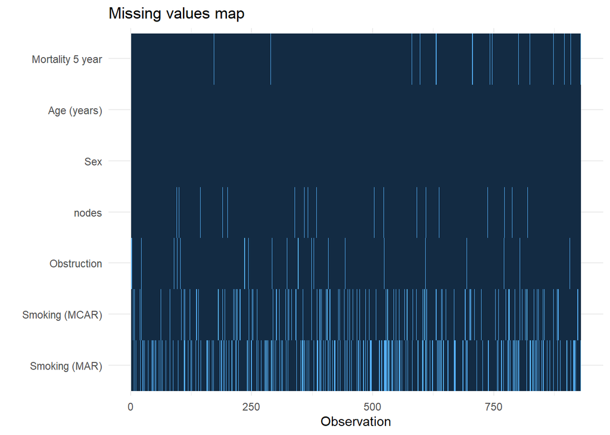

```r
# Missing values map
colon_s %>%
finalfit::missing_plot(dependent, explanatory)
```

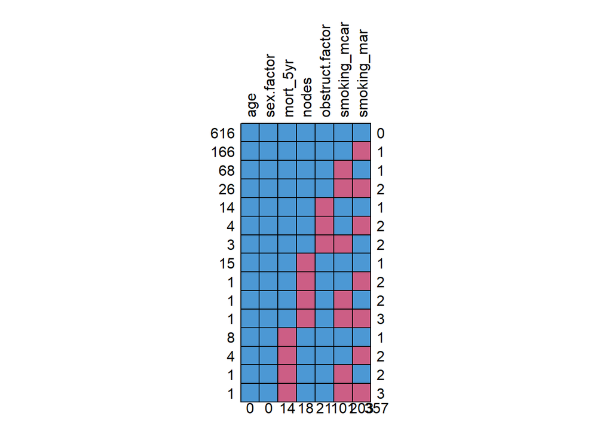

```
    age sex.factor mort_5yr nodes obstruct.factor smoking_mcar smoking_mar
616   1          1        1     1               1            1           1   0
166   1          1        1     1               1            1           0   1
68    1          1        1     1               1            0           1   1
26    1          1        1     1               1            0           0   2
14    1          1        1     1               0            1           1   1
4     1          1        1     1               0            1           0   2
3     1          1        1     1               0            0           1   2
15    1          1        1     0               1            1           1   1
1     1          1        1     0               1            1           0   2
1     1          1        1     0               1            0           1   2
1     1          1        1     0               1            0           0   3
8     1          1        0     1               1            1           1   1
4     1          1        0     1               1            1           0   2
1     1          1        0     1               1            0           1   2
1     1          1        0     1               1            0           0   3
      0          0       14    18              21          101         203 357
```

```r
# Look for ptterns of missingness
colon_s %>%
finalfit::missing_pattern(dependent, explanatory)
```

```r
# Including missing data in demographics tables
table1 <- colon_s %>%
  summary_factorlist(
    dependent = dependent,
    explanatory = explanatory,
    na_include = TRUE,
    na_include_dependent = TRUE,
    total_col = TRUE,
    add_col_totals = TRUE,
    p = TRUE,
    p_cont_para = "aov",
    p_cat = "chisq"
  )

knitr::kable(
  table1,
  caption = "Simulated missing completely at random (MCAR) and missing at random (MAR) dataset."
)
```

Simulated missing completely at random (MCAR) and missing at random (MAR) dataset.

| label | levels | Alive | Died | (Missing) | Total | p |
| --- | --- | --- | --- | --- | --- | --- |
| Total N (%) |  | 511 (55.0) | 404 (43.5) | 14 (1.5) | 929 |  |
| Age (years) | Mean (SD) | 59.8 (11.4) | 59.9 (12.5) | 53.9 (12.7) | 59.8 (11.9) | 0.986 |
| Sex | Female | 243 (47.6) | 194 (48.0) | 8 (57.1) | 445 (47.9) | 0.941 |
|  | Male | 268 (52.4) | 210 (52.0) | 6 (42.9) | 484 (52.1) |  |
|  | (Missing) | 0 (0.0) | 0 (0.0) | 0 (0.0) | 0 (0.0) |  |
| nodes | Mean (SD) | 2.7 (2.4) | 4.9 (4.4) | 2.9 (2.8) | 3.7 (3.6) | <0.001 |
| Obstruction | No | 408 (79.8) | 312 (77.2) | 12 (85.7) | 732 (78.8) | 0.219 |
|  | Yes | 89 (17.4) | 85 (21.0) | 2 (14.3) | 176 (18.9) |  |
|  | (Missing) | 14 (2.7) | 7 (1.7) | 0 (0.0) | 21 (2.3) |  |
| Smoking (MCAR) | Non-smoker | 358 (70.1) | 277 (68.6) | 10 (71.4) | 645 (69.4) | 0.133 |
|  | Smoker | 90 (17.6) | 91 (22.5) | 2 (14.3) | 183 (19.7) |  |
|  | (Missing) | 63 (12.3) | 36 (8.9) | 2 (14.3) | 101 (10.9) |  |
| Smoking (MAR) | Non-smoker | 312 (61.1) | 266 (65.8) | 7 (50.0) | 585 (63.0) | 0.082 |
|  | Smoker | 87 (17.0) | 52 (12.9) | 2 (14.3) | 141 (15.2) |  |
|  | (Missing) | 112 (21.9) | 86 (21.3) | 5 (35.7) | 203 (21.9) |  |

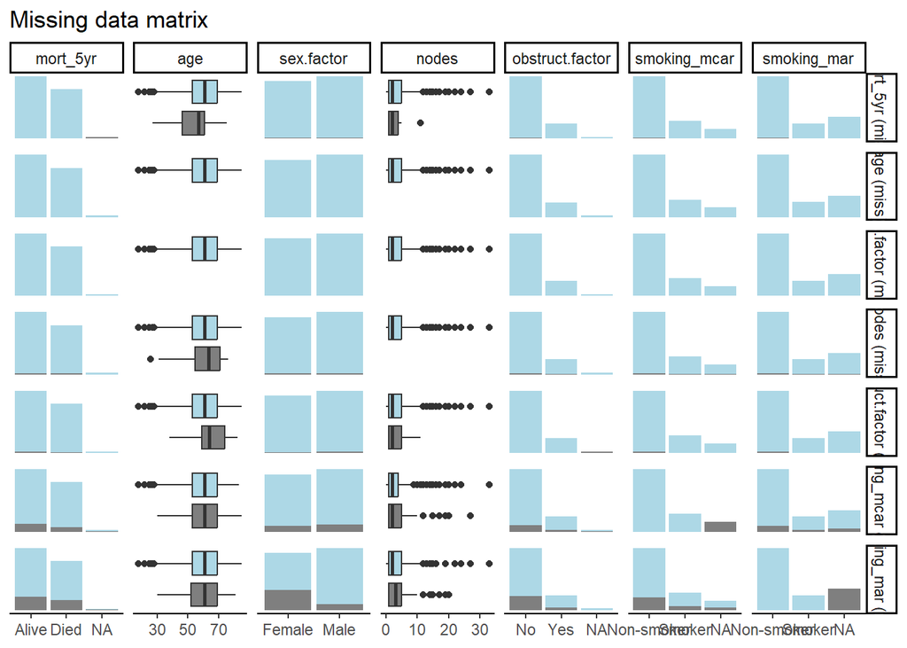

```r
# check for associations bewtwwen missing and observed data
dependent <- "mort_5yr"
explanatory <- c("age", "sex.factor", "nodes", "obstruct.factor", "smoking_mcar", "smoking_mar")
colon_s %>%
  missing_pairs(
    dependent = dependent,
    explanatory = explanatory,
    title = "Missing data matrix",
    use_labels = FALSE,
    showYAxisPlotLabels = FALSE
  )
```

```r
# MCAR
dependent <- "smoking_mcar"
explanatory <- c("age", "sex.factor", "nodes", "obstruct.factor")

missing_mcar <- colon_s %>%
  missing_compare(
    dependent = dependent,
    explanatory = explanatory
  )

knitr::kable(missing_mcar)
```

| Missing data analysis: Smoking (MCAR) |  | Not missing | Missing | p |
| --- | --- | --- | --- | --- |
| Age (years) | Mean (SD) | 59.7 (11.9) | 59.9 (12.6) | 0.882 |
| Sex | Female | 399 (89.7) | 46 (10.3) | 0.692 |
|  | Male | 429 (88.6) | 55 (11.4) |  |
| nodes | Mean (SD) | 3.6 (3.4) | 4.0 (4.5) | 0.302 |
| Obstruction | No | 654 (89.3) | 78 (10.7) | 0.891 |
|  | Yes | 156 (88.6) | 20 (11.4) |  |

```r
# MAR
dependent <- "smoking_mar"
explanatory <- c("age", "sex.factor", "nodes", "obstruct.factor")

missing_mar <- colon_s %>%
  missing_compare(
    dependent = dependent,
    explanatory = explanatory
  )

knitr::kable(missing_mar)
```

| Missing data analysis: Smoking (MAR) |  | Not missing | Missing | p |
| --- | --- | --- | --- | --- |
| Age (years) | Mean (SD) | 59.9 (11.8) | 59.4 (12.6) | 0.632 |
| Sex | Female | 288 (64.7) | 157 (35.3) | <0.001 |
|  | Male | 438 (90.5) | 46 (9.5) |  |
| nodes | Mean (SD) | 3.6 (3.5) | 3.9 (3.9) | 0.321 |
| Obstruction | No | 568 (77.6) | 164 (22.4) | 0.533 |
|  | Yes | 141 (80.1) | 35 (19.9) |  |

```r
dependent <- "mort_5yr"
explanatory <- c("age", "sex.factor", "nodes", "obstruct.factor", "smoking_mcar")

fit <- colon_s %>%
  finalfit(dependent, explanatory)
```

```
Note: dependent includes missing data. These are dropped.
```

```r
knitr::kable(fit, caption = "Regression analysis with missing data: List-wise deletion")
```

Regression analysis with missing data: List-wise deletion

|  | Dependent: Mortality 5 year |  | Alive | Died | OR (univariable) | OR (multivariable) |
| --- | --- | --- | --- | --- | --- | --- |
| 1 | Age (years) | Mean (SD) | 59.8 (11.4) | 59.9 (12.5) | 1.00 (0.99-1.01, p=0.986) | 1.01 (1.00-1.02, p=0.200) |
| 5 | Sex | Female | 243 (55.6) | 194 (44.4) | - | - |
| 6 |  | Male | 268 (56.1) | 210 (43.9) | 0.98 (0.76-1.27, p=0.889) | 1.02 (0.76-1.38, p=0.872) |
| 2 | nodes | Mean (SD) | 2.7 (2.4) | 4.9 (4.4) | 1.24 (1.18-1.30, p<0.001) | 1.25 (1.18-1.33, p<0.001) |
| 3 | Obstruction | No | 408 (56.7) | 312 (43.3) | - | - |
| 4 |  | Yes | 89 (51.1) | 85 (48.9) | 1.25 (0.90-1.74, p=0.189) | 1.53 (1.05-2.22, p=0.027) |
| 7 | Smoking (MCAR) | Non-smoker | 358 (56.4) | 277 (43.6) | - | - |
| 8 |  | Smoker | 90 (49.7) | 91 (50.3) | 1.31 (0.94-1.82, p=0.113) | 1.37 (0.96-1.96, p=0.083) |

```r
dependent <- "mort_5yr"
explanatory <- c("age", "sex.factor", "nodes", "obstruct.factor", "smoking_mar")

fit_explicit_na <- colon_s %>%
  mutate(smoking_mar = forcats::fct_na_value_to_level(smoking_mar)) %>%
  finalfit(dependent, explanatory)
```

```
Note: dependent includes missing data. These are dropped.
```

```r
knitr::kable(fit_explicit_na, row.names = FALSE)
```

| Dependent: Mortality 5 year |  | Alive | Died | OR (univariable) | OR (multivariable) |
| --- | --- | --- | --- | --- | --- |
| Age (years) | Mean (SD) | 59.8 (11.4) | 59.9 (12.5) | 1.00 (0.99-1.01, p=0.986) | 1.01 (1.00-1.02, p=0.114) |
| Sex | Female | 243 (55.6) | 194 (44.4) | - | - |
|  | Male | 268 (56.1) | 210 (43.9) | 0.98 (0.76-1.27, p=0.889) | 0.95 (0.71-1.28, p=0.743) |
| nodes | Mean (SD) | 2.7 (2.4) | 4.9 (4.4) | 1.24 (1.18-1.30, p<0.001) | 1.25 (1.19-1.32, p<0.001) |
| Obstruction | No | 408 (56.7) | 312 (43.3) | - | - |
|  | Yes | 89 (51.1) | 85 (48.9) | 1.25 (0.90-1.74, p=0.189) | 1.35 (0.95-1.92, p=0.099) |
| Smoking (MAR) | Non-smoker | 312 (54.0) | 266 (46.0) | - | - |
|  | Smoker | 87 (62.6) | 52 (37.4) | 0.70 (0.48-1.02, p=0.067) | 0.78 (0.52-1.17, p=0.233) |
|  |  | 112 (56.6) | 86 (43.4) | 0.90 (0.65-1.25, p=0.528) | 0.85 (0.59-1.23, p=0.390) |

```r
# Multivariate Imputation
dependent <- "mort_5yr"
explanatory <- c("age", "sex.factor", "nodes", "obstruct.factor", "smoking_mar")
colon_s %>%
  select(dependent, explanatory) %>%
  missing_predictorMatrix(drop_from_imputed = c("mort_5yr")) -> predM
fits <- colon_s %>%
  select(dependent, explanatory) %>%
  mice(m = 10, predictorMatrix = predM) %>% # Run imputation with 10 imputed sets
  with(glm(formula(ff_formula(dependent, explanatory)),
          family = "binomial")) # Run logistic regression on each imputed set
# AICs
fits %>%
  getfit() %>%
  purrr::map(AIC) %>%
  unlist() %>%
  mean()
```

```
[1] 1193.216
```

```r
# Pool results
fits_pool <- fits %>%
  pool()
knitr::kable(fits_pool$pooled)
```

| term | m | estimate | ubar | b | t | dfcom | df | riv | lambda | fmi |
| --- | --- | --- | --- | --- | --- | --- | --- | --- | --- | --- |
| (Intercept) | 10 | -1.4501982 | 0.1566905 | 0.0095674 | 0.1672147 | 923 | 625.4584 | 0.0671653 | 0.0629380 | 0.0659201 |
| age | 10 | 0.0073772 | 0.0000355 | 0.0000012 | 0.0000368 | 923 | 789.0676 | 0.0369913 | 0.0356717 | 0.0381067 |
| sex.factorMale | 10 | 0.0342079 | 0.0194230 | 0.0004106 | 0.0198746 | 923 | 855.8753 | 0.0232530 | 0.0227246 | 0.0250003 |
| nodes | 10 | 0.2089765 | 0.0006534 | 0.0000270 | 0.0006831 | 923 | 743.4049 | 0.0454546 | 0.0434783 | 0.0460413 |
| obstruct.factorYes | 10 | 0.2919575 | 0.0304573 | 0.0005987 | 0.0311159 | 923 | 862.7930 | 0.0216240 | 0.0211663 | 0.0234274 |
| smoking_marSmoker | 10 | -0.2469609 | 0.0320638 | 0.0073386 | 0.0401362 | 923 | 170.8304 | 0.2517621 | 0.2011261 | 0.2103176 |

```
Note: dependent includes missing data. These are dropped.
```

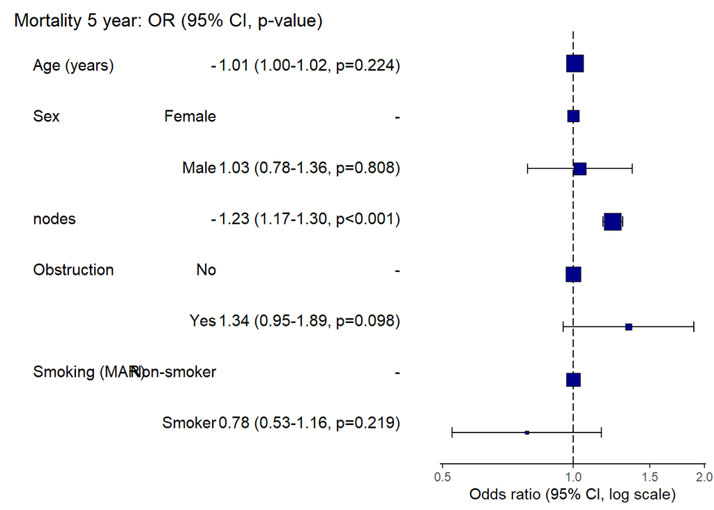

```r
colon_s %>%
  or_plot(dependent, explanatory, glmfit = fits_pool, table_text_size=4)
```

```r
fit_imputed <- fits_pool %>%
  fit2df(estimate_name = "OR (multiple imputation)", exp = TRUE)

explanatory <- c("age", "sex.factor", "nodes", "obstruct.factor", "smoking_mar")
table_uni_multi <- colon_s %>%
  finalfit(dependent, explanatory, keep_fit_id = TRUE)
```

```
Note: dependent includes missing data. These are dropped.
```

```r
explanatory = c("age", "sex.factor", "nodes", "obstruct.factor")
fit_multi_no_smoking <- colon_s %>%
  glmmulti(dependent, explanatory) %>%
  fit2df(estimate_suffix = " (multivariable without smoking)")
# Combine to final table
table_imputed <-
table_uni_multi %>%
  ff_merge(fit_multi_no_smoking) %>%
  ff_merge(fit_imputed, last_merge = TRUE)
knitr::kable(table_imputed, row.names = FALSE)
```

| Dependent: Mortality 5 year |  | Alive | Died | OR (univariable) | OR (multivariable) | OR (multivariable without smoking) | OR (multiple imputation) |
| --- | --- | --- | --- | --- | --- | --- | --- |
| Age (years) | Mean (SD) | 59.8 (11.4) | 59.9 (12.5) | 1.00 (0.99-1.01, p=0.986) | 1.02 (1.01-1.04, p=0.004) | 1.01 (1.00-1.02, p=0.122) | 1.01 (1.00-1.02, p=0.224) |
| Sex | Female | 243 (55.6) | 194 (44.4) | - | - | - | - |
|  | Male | 268 (56.1) | 210 (43.9) | 0.98 (0.76-1.27, p=0.889) | 0.97 (0.69-1.34, p=0.836) | 0.98 (0.74-1.30, p=0.890) | 1.03 (0.78-1.36, p=0.808) |
| nodes | Mean (SD) | 2.7 (2.4) | 4.9 (4.4) | 1.24 (1.18-1.30, p<0.001) | 1.28 (1.21-1.37, p<0.001) | 1.25 (1.19-1.32, p<0.001) | 1.23 (1.17-1.30, p<0.001) |
| Obstruction | No | 408 (56.7) | 312 (43.3) | - | - | - | - |
|  | Yes | 89 (51.1) | 85 (48.9) | 1.25 (0.90-1.74, p=0.189) | 1.49 (1.00-2.22, p=0.052) | 1.36 (0.95-1.93, p=0.089) | 1.34 (0.95-1.89, p=0.098) |
| Smoking (MAR) | Non-smoker | 312 (54.0) | 266 (46.0) | - | - | - | - |
|  | Smoker | 87 (62.6) | 52 (37.4) | 0.70 (0.48-1.02, p=0.067) | 0.77 (0.51-1.16, p=0.221) | - | 0.78 (0.53-1.16, p=0.219) |

# 5 Summary

The document “Introduction to Missing Data” provides an extensive overview of techniques to address missing data in statistical analysis. It explains the nature of missing data and its impact on analysis, explores conventional methods like case deletion and weighting, and discusses single and multiple imputation techniques. Single imputation methods, which replace missing values with a single estimate, are contrasted with multiple imputation approaches that create several datasets for robust statistical inference. The document also includes practical applications through a case study, demonstrating how these methods can be implemented in real-world data analysis to manage the challenges posed by missing data effectively.

# 6 References

1. ChatGPT4